# Taller 2

Maria Fernanda Palacio, David Santiago Alsina, Estefania Laverde

#### 1. Las siguientes son 5 medidas sobre las variables $x_1, x_2, x_3$:

Calculamos las medias de cada variable:

```r
x1 = c(9, 2, 6, 5, 8)
x2 = c(12, 8, 6, 4, 10)
x3 = c(3, 4, 0, 2, 1)

df = data.frame(x1, x2, x3)
mean = colMeans(df)
mean
```

```
## x1 x2 x3
##  6  8  2
```

```r
s = cov(df)
s
```

```
##       x1   x2    x3
## x1  7.50  5.0 -1.75
## x2  5.00 10.0  1.50
## x3 -1.75  1.5  2.50
```

Obtenemos la matriz $R$:

```r
r = cor(df)
r
```

```
##            x1        x2         x3
## x1  1.0000000 0.5773503 -0.4041452
## x2  0.5773503 1.0000000  0.3000000
## x3 -0.4041452 0.3000000  1.0000000
```

#### 2. Sea $x' = [5, 1, 3]$ y $y = [-1, 3 1]$

**A) Grafique los vectores.**

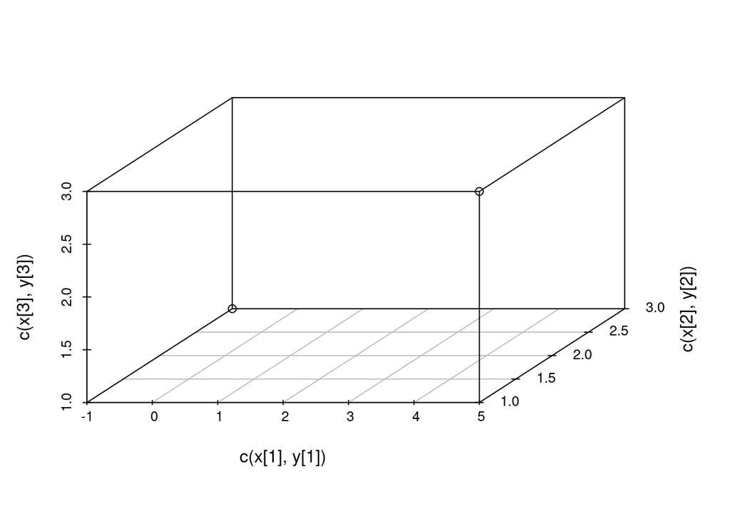

```r
x = c(5, 1, 3)
y = c(-1, 3, 1)

scatterplot3d( x = c(x[1], y[1]), y = c(x[2], y[2]), z = c(x[3], y[3]))
```

**B) Encuentre:**

- Longitud de x:

```r
x_lenght = sqrt(x%*%x)
x_lenght
```

```
##         [,1]
## [1,] 5.91608
```

- Ángulo entre $x$ e $y$, recordemos $cos(\theta) = \frac{x \cdot y}{||x|| \cdot ||y||}$

```r
theta = acos( (x%*%y)/(sqrt(x%*%x)*sqrt(y%*%y)) )
theta = theta*180/pi
theta
```

```
##          [,1]
## [1,] 87.07867
```

- Proyección de $y$ en $x$:

```r
proyection <- function(a, b){
  #proyecta b en a
  p = ((b%*%a)/(a%*%a))*a
  return(p)
}

proyection(x, y)
```

```
## [1] 0.14285714 0.02857143 0.08571429
```

**C) Dado que $\bar{x} = 3$, y $\bar{y} = 1$, grafique $x-\bar{x}$ y $y-\bar{y}$:**

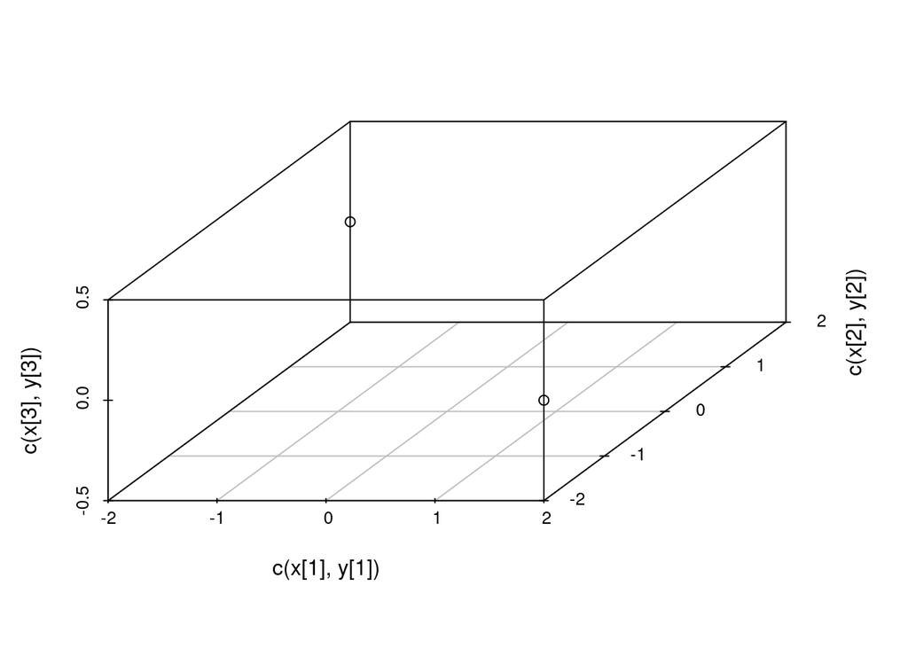

```r
x = x - 3
y = y - 1

scatterplot3d( x = c(x[1], y[1]), y = c(x[2], y[2]), z = c(x[3], y[3]))
```

#### 3. Sea la matriz A:

```r
A = cbind(c(9, -2), c(-2, 6))
A
```

```
##      [,1] [,2]
## [1,]    9   -2
## [2,]   -2    6
```

- ¿Es simétrica? **(si es simétrica, pues su transpuesta es igual a la matriz)**

```r
t(A) == A
```

```
##      [,1] [,2]
## [1,] TRUE TRUE
## [2,] TRUE TRUE
```

- Muestre que *A* es definida positiva, *(dado que todos los eigenvalues son positivos A es definida positiva)*:

```r
ans = eigen(A)
ans$values
```

```
## [1] 10  5
```

Para calcular los eigenvectores con cada eigenvalor, se desarrolla el siguiente procedimiento: - $\lambda =10$:

$$\left(\begin{array}{cc}
-1 & -2\\
-2 & -4
\end{array}\right)
\left(\begin{array}{cc}
x\\
y
\end{array}\right) =
\left(\begin{array}{cc}
0\\
0
\end{array}\right)$$
Luego se tiene el sistema de ecuaciones:

$$-x-2y = 0$$
$$-2x-4y = 0$$
Y al resolverlo se tiene entonces que
$$V1 = \left(\begin{array}{cc}
-2a\\
a
\end{array}\right), \forall a \in \mathbf{R}$$
Si tomamos al valor $a$ como 1, y lo dividimos entre su módulo ($\sqrt{5}$), se obtiene el eigenvector conseguido con el código.

El mismo procedimeinto se realiza con $\lambda = 5$, y se obtiene el eigenvector

$$V1 = \left(\begin{array}{cc}
a\\
2a
\end{array}\right), \forall a \in \mathbf{R}$$
Al tomar $a$ como 1, y dividiéndolo entre su módulo ($\sqrt{5}$), se obtiene el vector del código enseñado a continuación.

```r
ans$vectors
```

```
##            [,1]       [,2]
## [1,] -0.8944272 -0.4472136
## [2,]  0.4472136 -0.8944272
```

- La matriz de descomposición espectral es:

```r
A1 = ans$values[1]*ans$vectors[,1] %*% t(ans$vector[,1])
A1
```

```
##      [,1] [,2]
## [1,]    8   -4
## [2,]   -4    2
```

```r
A2 = ans$values[2]*ans$vectors[,2] %*% t(ans$vector[,2])
A2
```

```
##      [,1] [,2]
## [1,]    1    2
## [2,]    2    4
```

```r
desc = A1+A2
desc
```

```
##      [,1] [,2]
## [1,]    9   -2
## [2,]   -2    6
```

Como A1 y A2 forman A, estas son las componentes de la descomposición espectral.

- La inversa de A es:

```r
A_inv = solve(A)
A_inv
```

```
##      [,1] [,2]
## [1,] 0.12 0.04
## [2,] 0.04 0.18
```

- Encuentre los valores y vectores propios de $A^{-1}$:

```r
ans2 = eigen(A_inv)
print(ans2$values)
```

```
## [1] 0.2 0.1
```

```r
print(ans$vectors)
```

```
##            [,1]       [,2]
## [1,] -0.8944272 -0.4472136
## [2,]  0.4472136 -0.8944272
```

#### 4. Verifique las relaciones $V^{1/2}\rho V^{1/2} = \Sigma$ y $(V^{1/2})^{-1} \Sigma (V^{1/2})^{-1} = \rho$, donde $\Sigma$ es la $pxp$ matriz de covarianza poblacional, $\rho$ es la matriz de correlación poblacional pxp y $V^{1/2}$ es la natriz de desviación estándar de la población.

Sea $V^{1/2}\rho V^{1/2} = \Sigma$, queremos verificar que $\rho = (V^{1/2})^{-1} \Sigma (V^{1/2})^{-1}$.

Sustituyendo el valor de $\Sigma$ en la segunda ecuación se obtiene $(V^{1/2})^{-1} [V^{1/2}\rho V^{1/2}] (V^{1/2})^{-1}$

Note que $[(V^{1/2})^{-1} V^{1/2}] = [V^{1/2} (V^{1/2})^{-1}] = I$.

Y por lo tanto, $(V^{1/2})^{-1} [V^{1/2}\rho V^{1/2}] (V^{1/2})^{-1} = I \rho I = \rho$.

Por otro lado, conociendo que $\rho = (V^{1/2})^{-1} \Sigma (V^{1/2})^{-1}$ queremos verificar que $V^{1/2}\rho V^{1/2} = \Sigma$.

De la misma manera, sustituimos el valor de $\rho$ en la segunda ecuación de modo que $V^{1/2}[(V^{1/2})^{-1} \Sigma (V^{1/2})^{-1}]V^{1/2} = I \Sigma I = \Sigma$

Concluimos así que las relaciones se cumplen.

#### 5. Derive las expresiones para la media y las varianzas de las siguientes combinaciones lineales en terminos de ls¿as meduas y covaruanzas de las variables aleatorias $X_1$, $X_2$ y $X_3$.

**A) $X_1-2X_2$**

$E(X_1-2X_2) = E(X_1)-2E(X_2)$

**B) $-X_1+3X_2$**

$E(-X_1+3X_2) = -E(X_1)+3E(X_2)$

$var(-X_1+3X_2) = var(-X_1)+9var(X_2)+2cov(-X_1,3X_2) = var(X_1)+9var(X_2)-6cov(X_1,X_2)$

**C) $X_1+X_2+X_3$**

$E(X_1+X_2+X_3) = E(X_1)+E(X_2)+E(X_3)$

$var(X_1+X_2+X_3) = var(X_1)+var(X_2+X_3)+2cov(X_1,X_2+X_3) =$

$=var(X_1)+var(X_2)+var(X_3)+2cov(X_2,X_3)+2cov(X_1,X_2)+2cov(X_1,X_3)$

**D) $X_1+2X_2-X_3$**

$E(X_1+2X_2-X_3) = E(X_1)+2E(X_2)-E(X_3)$

$var(X_1+2X_2-X_3)= var(X_1)+var(2X_2-X_3)+2cov(X_1,2X_2-X_3) =$

$var(X_1)+4var(X_2)+var(X_3)-4cov(X_2,X_3)+4cov(X_1,X_2)-2cov(X_1,X_3)$

**E) $3X_1-4X_2$ si $X_1$ y $X_2$ son independientes.**

$E(3X_1-4X_2) = 3E(X_1)-4E(X_2)$

$var(3X_1-4X_2)=9var(X_1)+16var(X_2)$

#### 6. Dada la matriz de datos

```r
a = c(9,5,1)
b = c(1, 3, 2)

X = cbind(a, b)
X
```

```
##      a b
## [1,] 9 1
## [2,] 5 3
## [3,] 1 2
```

**A) Grafique el diagrama de dispersion en $p=2$ dimensiones. Localice la media de la muestra en su diagrama**

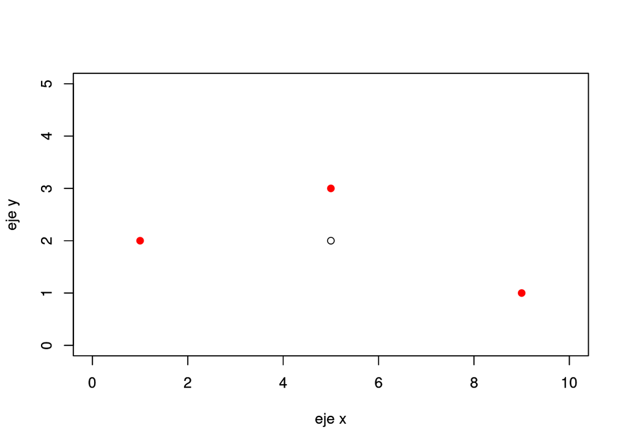

```r
plot(X, xlim=range(0,10), pch=19, col="red",
     ylim=range(0, 5), xlab='eje x', ylab='eje y')
par(new=T)
plot(mean(a), mean(b), xlim=range(0,10), ylim=range(0,5), xlab='eje x', ylab='eje y')
```

**B) Dibuje la representación $n=3$ -dimensional de los datos y trace vectores de desviación $y_{1} - \bar{x}_{1} \cdot 1$**

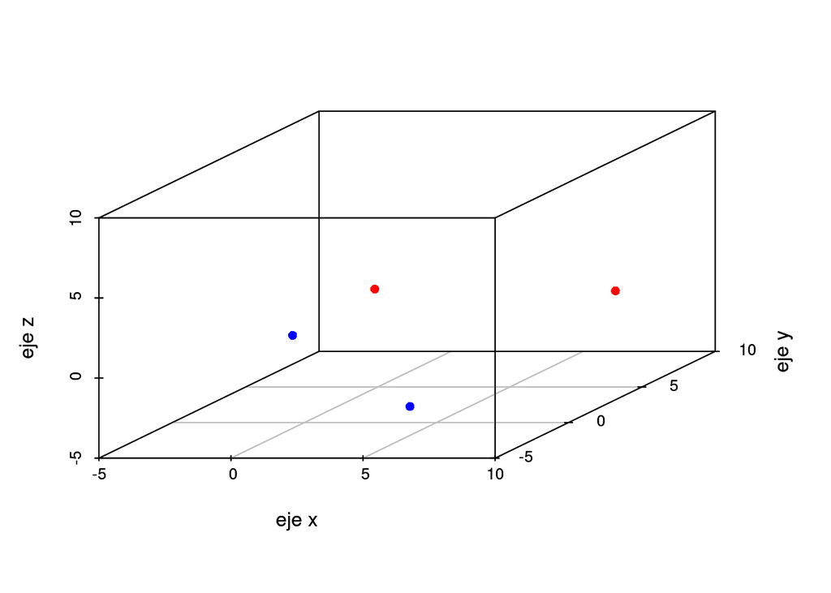

```r
X = cbind(a, b)

scatterplot3d(x = X[1,], y = X[2,], z = X[3,], xlab = "eje x", ylab = "eje y",
              zlab = "eje z", pch = 16, color = 'red',
              xlim=c(-5,10), ylim=c(-5,10), zlim =c(-5,10))
par(new=T)

x1_mean = mean(X[,1])
x2_mean = mean(X[,2])
X[,1] = X[,1] - x1_mean
X[,2] = X[,2] - x2_mean

scatterplot3d(x = X[1,], y = X[2,], z = X[3,], xlab = "eje x", ylab = "eje y",
              zlab = "eje z", pch = 16, color = 'blue',
              xlim=c(-5,10), ylim=c(-5,10), zlim = c(-5, 10))
```

**C) Dibuje los vectores de desviación en $(B)$ que emanan del origen. Calcula las longitudes de estos vectores y del coseno del ángulo entre ellos. Relacione estas cantidades con $S_{n}$ y $R$.**

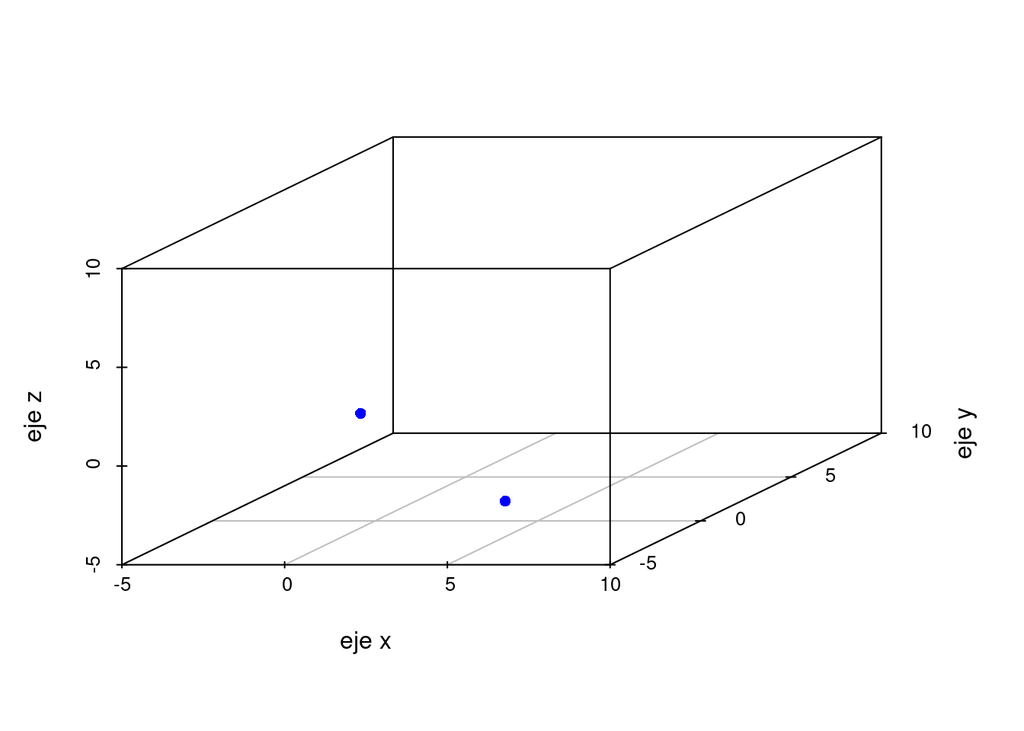

```r
scatterplot3d(x = X[1,], y = X[2,], z = X[3,], xlab = "eje x", ylab = "eje y",
              zlab = "eje z", pch = 16, color = 'blue',
              xlim=c(-5,10), ylim=c(-5,10), zlim = c(-5, 10))
```

```r
print(paste("longitud del vector x1: ", sqrt(X[,1]%*%X[,1]) ) )
```

```
## [1] "longitud del vector x1:  5.65685424949238"
```

```r
print(paste("longitud del vector x2: ", sqrt(X[,2]%*%X[,2]) ) )
```

```
## [1] "longitud del vector x2:  1.4142135623731"
```

```r
print(paste("coseno del angulo entre ellos: ",
            (X[,1]%*%X[,2])/(sqrt(X[,1]%*%X[,1])*sqrt(X[,2]%*%X[,2]))  ))
```

```
## [1] "coseno del angulo entre ellos:  -0.5"
```

Note que el coseno del ángulo entre los vectores es la correlación ($R$) entre sus cantidades.

```r
cor(X)
```

```
##      a    b
## a  1.0 -0.5
## b -0.5  1.0
```

#### 7. Demuestre que $|S| = (s_{11}s_{22}...s_{pp})|R|$

Queremos mostrar que $|S| = (S_{11}S_{22}...S_{pp})|R|$. Como $R = D^{-\frac{1}{2}}S D^{-\frac{1}{2}}$, donde $D^{-\frac{1}{2}}$ es una matriz triangular cuyo determinante esta dado por el producto de los elementos de su diagonal principal, es decir, $\frac{1}{\sqrt{S11}\sqrt{S22}...\sqrt{Spp}}$, podemos escribir el lado derecho de la igualdad como $(s_{11}s_{22}...s_{pp})|R| = (s_{11}s_{22}...s_{pp})|D^{-\frac{1}{2}}S D^{-\frac{1}{2}}| = (s_{11}s_{22}...s_{pp})|D^{-\frac{1}{2}}||S|| D^{-\frac{1}{2}}|=$

$=(s_{11}s_{22}...s_{pp})\frac{1}{\sqrt{S11}\sqrt{S22}...\sqrt{Spp}}|S|\frac{1}{\sqrt{S11}\sqrt{S22}...\sqrt{Spp}} = (s_{11}s_{22}...s_{pp})\frac{1}{S11S22...Spp}|S|=|S|$

#### 8. Sea $V$ una variable aleatoria vectorial con un vector medio $E(v) = \mu_{v}$ y una matriz de covarianza $E((V - \mu_{v})\cdot (V - \mu_{v})') = \Sigma_{v}$. Demuestre que:

$E(VV') = \Sigma_{v} + \mu_{v}\mu_{v}'$

Para esta demostracion nos valdremos de las siguientes propiedades. Sean $x$ e $y$ variables aleatorias: $var(x) = E(x^2) - E(x)^2$, $cov(x, y) = E(xy) - E(x)E(y)$.

Empecemos por analizar la forma de $VV'$:

$$VV' = \begin{bmatrix}
x_{1} \\ x_{2} \\ \vdots \\ x_{n}
\end{bmatrix}
\begin{bmatrix}
x_{1} & x_{2} & \dots & x_{n}
\end{bmatrix} =
\begin{bmatrix}
x_{1}^{2} & \dots & x_{i + n}x_{1} \\
\vdots & \ddots & \vdots \\
x_{n}x_{1} & \dots & x_{i + n}^{2}
\end{bmatrix}$$

$$E(VV') = E\bigg(\begin{bmatrix}
x_{1} \\ x_{2} \\ \vdots \\ x_{n}
\end{bmatrix}
\begin{bmatrix}
x_{1} & x_{2} & \dots & x_{n}
\end{bmatrix}\bigg) =
\begin{bmatrix}
E(x_{1}^{2}) & \dots & E(x_{i + n}x_{1}) \\
\vdots & \ddots & \vdots \\
E(x_{n}x_{1}) & \dots & E(x_{i + n}^{2})
\end{bmatrix}$$

Vea que $\mu_{v}\mu_{v}'$ es otra matriz de la forma:

$$\mu_{v}\mu_{v}' = \begin{bmatrix}
\mu_{1} \\ \mu_{2} \\ \vdots \\ \mu_{n}
\end{bmatrix}
\begin{bmatrix}
\mu_{1} & \mu_{2} & \dots & \mu_{n}
\end{bmatrix} =
\begin{bmatrix}
\mu_{1}^{2} & \dots & \mu_{i + n}\mu_{1} \\
\vdots & \ddots & \vdots \\
\mu_{n}\mu_{1} & \dots & \mu_{i + n}^{2}
\end{bmatrix}$$

Tenemos entonces que:

$$\Sigma_{v} =
\begin{bmatrix}
E(x_{1}^{2}) & \dots & E(x_{i + n}x_{1}) \\
\vdots & \ddots & \vdots \\
E(x_{n}x_{1}) & \dots & E(x_{i + n}^{2})
\end{bmatrix} -
\begin{bmatrix}
\mu_{1}^{2} & \dots & \mu_{i + n}\mu_{1} \\
\vdots & \ddots & \vdots \\
\mu_{n}\mu_{1} & \dots & \mu_{i + n}^{2}
\end{bmatrix}
=
\begin{bmatrix}
s_{1}^{2} & \dots & s_{i + n}s_{1} \\
\vdots & \ddots & \vdots \\
s_{n}s_{1} & \dots & s_{i + n}^{2}
\end{bmatrix}$$
Esto es válido porque sabemos que dado $x$ e $y$ variables aleatorias: $var(x) = E(x^2) - E(x)^2$, $cov(x, y) = E(xy) - E(x)E(y)$.

Reordenando todo:

$$\Sigma_{v} +
\begin{bmatrix}
\mu_{1}^{2} & \dots & \mu_{i + n}\mu_{1} \\
\vdots & \ddots & \vdots \\
\mu_{n}\mu_{1} & \dots & \mu_{i + n}^{2}
\end{bmatrix} = \Sigma_{v} + \mu_{v}\mu_{v}' =
\begin{bmatrix}
E(x_{1}^{2}) & \dots & E(x_{i + n}x_{1}) \\
\vdots & \ddots & \vdots \\
E(x_{n}x_{1}) & \dots & E(x_{i + n}^{2})
\end{bmatrix}
= E(VV') \;\;
\blacksquare$$

#### 9) Considere una distribución normal bivariada con $\mu_{1} = 1$, $\mu_{2}=3$, $\sigma_{11} = 2$, $\sigma_{22} =1$ y $p_{12} =-.8$

**a)** Escriba la densidad normal bivariada.  
$p_{12} = \frac{\sigma_{12}}{\sqrt{\sigma_{11}}\sqrt{\sigma_{22}}}$  
$-.8 = \sigma_{12} \frac{1}{\sqrt{2}\sqrt{1}}$ $\sigma_{12} = -.8\sqrt{2}$

**b)** Escriba la expresión de distancia estadística al cuadrado $(x − \mu)′ \Sigma^{-1}(x − \mu)$ como una función cuadrática de $x_1$ y $x_2$.

$$(distancia)^{2} =\left( \begin{bmatrix}
x_1 \\
x_2
\end{bmatrix}- \left[\begin{array}
11 \\
3
\end{array}\right]\right)^{'} \begin{bmatrix}
1.3889 & 1.5713 \\
1.5713 & 2.7778
\end{bmatrix} \left( \begin{bmatrix}
x_{1} \\
x_{2}
\end{bmatrix} - \begin{bmatrix}
1 \\
3
\end{bmatrix}\right)$$

$$(distancia)^2 = \begin{bmatrix}
x_{1}-1 & x_{2}-3
\end{bmatrix} \begin{bmatrix}
1.3889 & 1.5713 \\
1.5713 & 2.7778
\end{bmatrix} \begin{bmatrix}
x_{1} -1 & x_{2}-3
\end{bmatrix}$$

$$(distancia)^2 = [\begin{array} {cc}
1.3889(x_1 -1) + 1.5713(x_2 -3) & 1.5713(x_1 -1)+2.7778(x_2 -3) \end{array} ] \left[ \begin{array}{cc}
x_{1} -1 \\
x_{2}-3
\end{array} \right]$$

$$(distancia)^2 = 1.3889(x_1 -1)^2 + 1.5713(x_2 -3)(x_1 -1) + 1.5713(x_1 -1)(x_2 -3) + 2.7778(x_2 -3)$$

#### 10) Sea $X$ $N_{3}(\mu, \Sigma)$ con $\mu^{'} = [-3,1,4]$ y

$$\left(\begin{array} {cc}
1 & -2 & 0\\
-2 & 5 & 0 \\
0 & 0 & 2
\end{array}\right)$$

A)$X_{1}$ y $X_{2}$

> $\sigma_{12} = \sigma_{21} = -2$ por lo tanto, son dependientes.

B)$X_{2}$ y $X_{3}$

> $\sigma_{13} = \sigma_{31} = 0$ por lo tanto, son independientes.